# Textual Analysis with Quanteda

Zhaofeng Tong

1. Getting Started.

   Install Packages

   ```r
   install.packages("quanteda")
   install.packages("readtext")
   ```

   ```r
   devtools::install_github('quanteda/quanteda.corpora')
   ```

2. Exploring **quanteda** functions.

   ```r
   library(tm)
   library(quanteda)
   library(quanteda.corpora)
   library(readtext)
   ```

3. Making a corpus and corpus structure

```r
a1<-corpus(data_char_ukimmig2010)
a2<-corpus(data_corpus_inaugural)
summary(a1)
summary(a2)
```

```r
library("quanteda", quietly = TRUE, warn.conflicts = FALSE)
```

3. Explore some phrases in the text.

   ```r
   kwic(data_corpus_inaugural, "terror",3)
   ```

   ```
   ##
   ##     [1797-Adams, 1325]             violence, by | terror |
   ##  [1933-Roosevelt, 112] unreasoning, unjustified | terror |
   ##  [1941-Roosevelt, 287]          by a fatalistic | terror |
   ##    [1961-Kennedy, 866]     uncertain balance of | terror |
   ##     [1981-Reagan, 813]       Americans from the | terror |
   ##   [1997-Clinton, 1055]        the fanaticism of | terror |
   ##   [1997-Clinton, 1655]   strong defense against | terror |
   ##     [2009-Obama, 1632]         aims by inducing | terror |
   ##
   ##  , intrigue,
   ##  which paralyzes needed
   ##  , we proved
   ##  that stays the
   ##  of runaway living
   ##  . And they
   ##  and destruction.
   ##  and slaughtering innocents
   ```

4. Create a document-feature matrix.

```r
mydfm <- dfm(data_corpus_inaugural, remove = stopwords("english"))
mydfm
```

```
## Document-feature matrix of: 58 documents, 9,221 features (92.6% sparse).
```

```r
topfeatures(mydfm, 20)
```

```
##          ,          .          -     people          ; government
##       7026       4945        762        575        565        564
##         us        can       upon       must      great        may
##        478        471        371        366        340        338
##     states      shall      world    country      every     nation
##        333        314        311        304        298        293
##      peace        one
##        254        252
```

Group by president

```r
mydfm <- dfm(data_corpus_inaugural, groups = "President")
mydfm
```

```
## Document-feature matrix of: 35 documents, 9,357 features (88.3% sparse).
```

```r
docnames(mydfm)
```

```
##  [1] "Adams"      "Buchanan"   "Bush"       "Carter"     "Cleveland"
##  [6] "Clinton"    "Coolidge"   "Eisenhower" "Garfield"   "Grant"
## [11] "Harding"    "Harrison"   "Hayes"      "Hoover"     "Jackson"
## [16] "Jefferson"  "Johnson"    "Kennedy"    "Lincoln"    "Madison"
## [21] "McKinley"   "Monroe"     "Nixon"      "Obama"      "Pierce"
## [26] "Polk"       "Reagan"     "Roosevelt"  "Taft"       "Taylor"
## [31] "Truman"     "Trump"      "Van Buren"  "Washington" "Wilson"
```

```r
mydfm1<-dfm(data_corpus_irishbudget2010,groups = "party")
docvars(mydfm1)
```

```
## data frame with 0 columns and 5 rows
```

5. Explore the ability to subset a corpus.

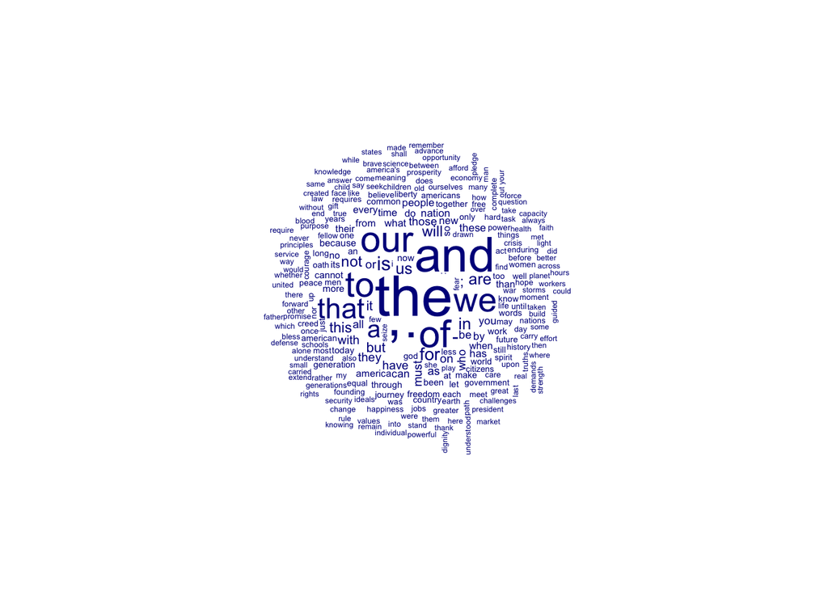

```r
    obamadfm <- dfm(corpus_subset(data_corpus_inaugural, President=="Obama"))
    textplot_wordcloud(obamadfm)
```

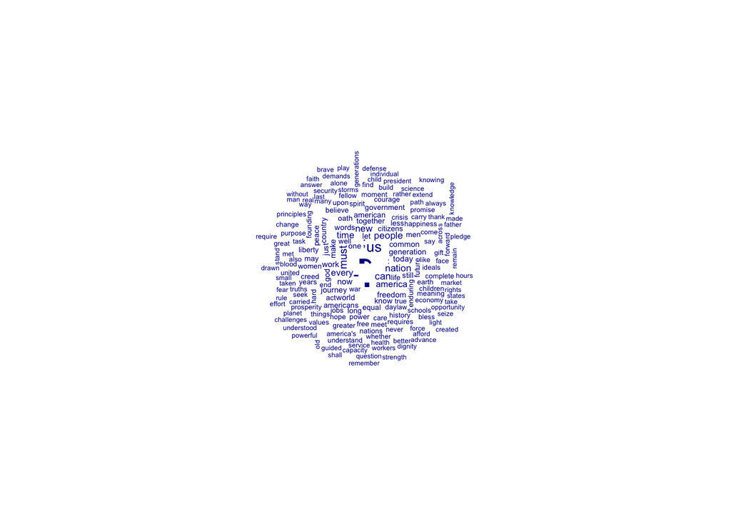

```r
am<-dfm_remove(obamadfm,stopwords("english"))
textplot_wordcloud(am)
```

1. **Preparing and pre-processing texts**

```r
data("data_char_sampletext")
char_tolower(data_char_sampletext,acronyms=TRUE)
```

```
## [1] "instead we have a fine gael-labour party government, coming into power promising real change but slavishly following the previous government’s policy. that policy has been dictated by the imf, the eu and the ecb not to bail out the irish people but to salvage german, french, british banks an…
```

```r
?tokens()
e<-tokens(data_char_sampletext,remove_symbols=TRUE,remove_punct=TRUE)
```

6. Tokenizing texts
7. Stemming.

```r
library(SnowballC)

char_wordstem(as.character(e),language = quanteda_options("language_stemmer"))
```

```
##   [1] "Instead"     "we"          "have"        "a"           "Fine"
##   [6] "Gael-Labour" "Parti"       "Govern"      "come"        "into"
##  [11] "power"       "promis"      "real"        "chang"       "but"
##  [16] "slavish"     "follow"      "the"         "previous"    "Govern"
##  [21] "polici"      "That"        "polici"      "has"         "been"
##  [26] "dictat"      "by"          "the"         "IMF"         "the"
##  [31] "EU"          "and"         "the"         "ECB"         "not"
##  [36] "to"          "bail"        "out"         "the"         "Irish"
##  [41] "peopl"       "but"         "to"          "salvag"      "German"
##  [46] "French"      "British"     "bank"        "and"         "those"
##  [51] "of"          "other"       "countri"     "from"        "their"
##  [56] "disastr"     "and"         "frenzi"      "embrac"      "of"
##  [61] "Irish"       "banker"      "and"         "specul"      "in"
##  [66] "the"         "Irish"       "properti"    "market"      "bubbl"
##  [71] "It"          "is"          "crimin"      "that"        "an"
```

[output cut: 84 more lines]

8. Applying “pre-processing” to the creation of a `dfm`.

```r
        require(tm)
        data("crude")
        crude <- tm_map(crude, content_transformer(tolower))
        crude <- tm_map(crude, removePunctuation)
        crude <- tm_map(crude, removeNumbers)
        crude <- tm_map(crude, stemDocument)
        tdm <- TermDocumentMatrix(crude)

        # same in quanteda
        require(quanteda)
        crudeCorpus <- corpus(crude)
        crudeDfm <- dfm(crudeCorpus, remove_punct = T, remove_numbers = T, stem = T)
        docnames(crudeDfm)
```

```
##  [1] "127" "144" "191" "194" "211" "236" "237" "242" "246" "248" "273"
## [12] "349" "352" "353" "368" "489" "502" "543" "704" "708"
```

```r
        topfeatures(crudeDfm)
```

```
##   the    to    of    in   oil     a   and  said    it price
##   232   135    97    86    85    77    77    73    66    63
```

```r
        dim(crudeDfm)
```

```
## [1]  20 874
```

This indicates that we can extract the names of the words from the **tm** TermDocumentMatrix object by getting the rownames from inspecting the tdm:

```r
head(tdm$dimnames$Terms, 848)
```

```
##   [1] "abdulaziz"        "abil"             "abl"
##   [4] "about"            "abov"             "abroad"
##   [7] "accept"           "accord"           "across"
##  [10] "activ"            "add"              "address"
##  [13] "adher"            "advantag"         "advis"
##  [16] "after"            "again"            "against"
##  [19] "agenc"            "agre"             "agreement"
##  [22] "agricultur"       "aground"          "ali"
##  [25] "alkhalifa"        "all"              "alloc"
##  [28] "allow"            "almost"           "along"
##  [31] "alqaba"           "alreadi"          "alsabah"
##  [34] "also"             "althani"          "although"
##  [37] "alvit"            "amidst"           "among"
##  [40] "analysi"          "analyst"          "and"
##  [43] "ani"              "announc"          "annual"
```

[output cut: 268 more lines]

Compare this to the results of the same operations from **quanteda**. To get the “words” from a quanteda object, you can use the `featnames()` function:

```r
features_quanteda <- featnames(crudeDfm) #874 features
head(features_quanteda, 20)
```

```
##  [1] "diamond"  "shamrock" "corp"     "said"     "that"     "effect"
##  [7] "today"    "it"       "had"      "cut"      "contract" "price"
## [13] "for"      "crude"    "oil"      "by"       "dlrs"     "a"
## [19] "barrel"   "the"
```

```r
str(crudeDfm)
```

```
## Formal class 'dfm' [package "quanteda"] with 15 slots
##   ..@ settings    : list()
##   ..@ weightTf    :List of 3
##   .. ..$ scheme: chr "count"
##   .. ..$ base  : NULL
##   .. ..$ K     : NULL
##   ..@ weightDf    :List of 5
##   .. ..$ scheme   : chr "unary"
##   .. ..$ base     : NULL
##   .. ..$ c        : NULL
##   .. ..$ smoothing: NULL
##   .. ..$ threshold: NULL
##   ..@ smooth      : num 0
##   ..@ ngrams      : int 1
##   ..@ skip        : int 0
##   ..@ concatenator: chr "_"
##   ..@ version     : int [1:3] 1 3 4
##   ..@ docvars     :'data.frame': 20 obs. of  15 variables:
##   .. ..$ datetimestamp: chr [1:20] "1987-02-26 17:00:56" "1987-02-26 17:34:11" "1987-02-26 18:18:00" "1987-02-26 18:21:01" ...
##   .. ..$ description  : chr [1:20] "" "" "" "" ...
##   .. ..$ heading      : chr [1:20] "DIAMOND SHAMROCK (DIA) CUTS CRUDE PRICES" "OPEC MAY HAVE TO MEET TO FIRM PRICES - ANALYSTS" "TEXACO CANADA <TXC> LOWERS CRUDE POSTINGS" "MARATHON PETROLEUM REDUCES CRUDE POSTINGS" ...
##   .. ..$ id           : chr [1:20] "127" "144" "191" "194" ...
##   .. ..$ language     : chr [1:20] "en" "en" "en" "en" ...
##   .. ..$ origin       : chr [1:20] "Reuters-21578 XML" "Reuters-21578 XML" "Reuters-21578 XML" "Reuters-21578 XML" ...
##   .. ..$ topics       : chr [1:20] "YES" "YES" "YES" "YES" ...
##   .. ..$ lewissplit   : chr [1:20] "TRAIN" "TRAIN" "TRAIN" "TRAIN" ...
##   .. ..$ cgisplit     : chr [1:20] "TRAINING-SET" "TRAINING-SET" "TRAINING-SET" "TRAINING-SET" ...
##   .. ..$ oldid        : chr [1:20] "5670" "5687" "5734" "5737" ...
##   .. ..$ places       : chr [1:20] "usa" "usa" "canada" "usa" ...
##   .. ..$ author       : chr [1:20] NA "BY TED D'AFFLISIO, Reuters" NA NA ...
##   .. ..$ orgs         : chr [1:20] NA "opec" NA NA ...
##   .. ..$ people       : chr [1:20] NA NA NA NA ...
##   .. ..$ exchanges    : chr [1:20] NA NA NA NA ...
##   ..@ i           : int [1:2086] 0 0 0 10 17 0 1 2 3 4 ...
##   ..@ p           : int [1:875] 0 1 2 5 25 36 41 48 65 69 ...
##   ..@ Dim         : int [1:2] 20 874
##   ..@ Dimnames    :List of 2
##   .. ..$ docs    : chr [1:20] "127" "144" "191" "194" ...
##   .. ..$ features: chr [1:874] "diamond" "shamrock" "corp" "said" ...
##   ..@ x           : num [1:2086] 2 1 1 3 1 3 11 1 1 3 ...
##   ..@ factors     : list()
```

What proportion of the `crudeDfm` are zeros? Compare the sizes of `tdm` and `crudeDfm` using the `object.size()` function.

```r
prop.table(table(as.matrix(crudeDfm)==0))
```

```
##
##     FALSE      TRUE
## 0.1193364 0.8806636
```

```r
print(object.size(crudeDfm), units= "Mb")
```

```
## 0.1 Mb
```

```r
print(object.size(tdm), units= "Mb")
```

```
## 0.1 Mb
```

1. **Keywords-in-context**

```r
a7<-corpus(data_corpus_irishbudget2010)
mykwic<-kwic(a7,"good",window = 3)
str(mykwic)
```

```
## Classes 'kwic' and 'data.frame': 26 obs. of  6 variables:
##  $ docname: chr  "2010_BUDGET_01_Brian_Lenihan_FF" "2010_BUDGET_01_Brian_Lenihan_FF" "2010_BUDGET_02_Richard_Bruton_FG" "2010_BUDGET_02_Richard_Bruton_FG" ...
##  $ from   : int  853 7889 3431 3690 2063 2227 2764 2886 2902 3175 ...
##  $ to     : int  853 7889 3431 3690 2063 2227 2764 2886 2902 3175 ...
##  $ pre    : chr  "between the common" "energy efficiency is" "doing us no" "be fair that" ...
##  $ keyword: chr  "good" "good" "good" "good" ...
##  $ post   : chr  "and narrower sectional" "for the environment" ". It was" "businesses are now" ...
##  - attr(*, "docid")= int  1 1 2 2 3 3 3 3 3 3 ...
##  - attr(*, "segid")= int  1 2 1 2 1 2 3 4 5 6 ...
##  - attr(*, "ntoken")= Named int  8641 4446 6393 7107 6599 4232 2297 4177 1286 1284 ...
##   ..- attr(*, "names")= chr  "2010_BUDGET_01_Brian_Lenihan_FF" "2010_BUDGET_02_Richard_Bruton_FG" "2010_BUDGET_03_Joan_Burton_LAB" "2010_BUDGET_04_Arthur_Morgan_SF" ...
##  - attr(*, "valuetype")= chr "glob"
##  - attr(*, "keywords")= chr "good"
##  - attr(*, "types")= chr  "When" "I" "presented" "the" ...
##  - attr(*, "padding")= logi FALSE
##  - attr(*, "what")= chr "word"
##  - attr(*, "ngrams")= int 1
##  - attr(*, "skip")= int 0
##  - attr(*, "concatenator")= chr "_"
##  - attr(*, "docvars")='data.frame':  14 obs. of  6 variables:
##   ..$ year  : chr  "2010" "2010" "2010" "2010" ...
##   ..$ debate: chr  "BUDGET" "BUDGET" "BUDGET" "BUDGET" ...
##   ..$ number: chr  "01" "02" "03" "04" ...
##   ..$ foren : chr  "Brian" "Richard" "Joan" "Arthur" ...
##   ..$ name  : chr  "Lenihan" "Bruton" "Burton" "Morgan" ...
##   ..$ party : chr  "FF" "FG" "LAB" "SF" ...
```

```r
?kwic
mykwic2<-kwic(a7,"disaster",window = 0)
```

1. **Descriptive statistics**
   1. We can extract basic descriptive statistics from a corpus from its document feature matrix. Make a dfm from the 2010 Irish budget speeches corpus.

```r
dfmm<-dfm(data_corpus_irishbudget2010)
?textstat_frequency
textstat_frequency(dfmm,n=5)
```

```
##   feature frequency rank docfreq group
## 1     the      3598    1      14   all
## 2       .      2371    2      14   all
## 3      to      1633    3      14   all
## 4       ,      1548    4      14   all
## 5      of      1537    5      14   all
```

```r
        # count syllables from texts in the 2010 speech corpus
        textsyls <- nsyllable(texts(data_corpus_irishbudget2010))
        # sum the syllable counts
        sum(textsyls)
```

```
## [1] 81720
```

```
    How would you get the total syllables per text?
```

3. **Lexical Diversity over Time**

```r
        data(data_corpus_irishbudgets, package = "quanteda.corpora")
        finMins <- corpus_subset(data_corpus_irishbudgets, number == "01")
        ?corpus_subset
        tokeninfo <- summary(finMins)
```

```r
q<-textstat_lexdiv(dfmm,measure="TTR")
str(q)
plot(q$TTR,data_corpus_irishbudget2010$year,type = "l")
summary(corpus(data_corpus_irishbudget2010))
plot(textstat_lexdiv(dfmm,measure = "TTR"))
```

[output not shown]

4. **Document and word associations**
   1. Load the presidential inauguration corpus selecting from 1900-1950, and create a dfm from this corpus.

```r
dfm1 <- dfm(corpus_subset(data_corpus_inaugural,Year>1900 & Year<1950))
```

```
2.  Measure the term similarities (`textstat_simil`) for the following words: *economy*, *health*,
    *women*. Which other terms are most associated with each of these three terms?
```

```r
?textstat_simil
textstat_simil(dfm1,selection = c("economy","health"),margin="features")
```

```
##                            economy       health
## my                     0.044049985  0.008583454
## fellow-citizens        0.019994669 -0.160714286
## ,                      0.535020269 -0.011394051
## when                   0.552069625 -0.278726754
## we                     0.617362637 -0.123542054
## assembled              0.014397807 -0.115727512
## here                   0.328426498 -0.226041789
## on                     0.054565431 -0.302835347
## the                    0.399861952  0.198919594
## 4th                    0.014397807 -0.115727512
## of                     0.458297754  0.339177648
## march                 -0.091059727 -0.219577516
## 1897                   0.014397807 -0.115727512
## there                  0.740937938 -0.052394895
## was                    0.175247112 -0.103943320
## great                  0.779691204  0.144642385
## anxiety               -0.209437373 -0.219577516
## with                   0.520850816  0.206934510
## regard                -0.036731271 -0.184525437
## to                     0.466397255  0.056173386
## our                    0.446095820  0.524070178
## currency               0.028500267 -0.104995488
## and                    0.455559525  0.107771428
## credit                 0.435476791 -0.129640745
## .                      0.680920153  0.211789433
## none                  -0.057007716 -0.203653270
## exists                 0.014397807 -0.115727512
## now                   -0.055126679 -0.314834464
## then                  -0.171492768 -0.378393734
## treasury               0.021266971  0.569802882
## receipts               0.021266971 -0.170940865
## were                   0.445681762  0.005307150
## inadequate            -0.153292461 -0.160714286
## meet                   0.420952434 -0.290774293
## current                0.465504357 -0.267261242
## obligations            0.451551994 -0.085199772
## government             0.341125990  0.460005387
## they                   0.505026093  0.228769437
## are                    0.584593190  0.258251738
```

[output cut: 4237 more lines]

[output not shown]

1. **Working with dictionaries**

```r
  posDict <- dictionary(list(articles = c("the", "a", "and"),
                                   conjunctions = c("and", "but", "or", "nor", "for", "yet", "so")))
```

```r
        posDfm <- dfm(data_corpus_inaugural, dictionary = posDict)
        posDfm[1:10,]
```

```
## Document-feature matrix of: 10 documents, 2 features (0% sparse).
## 10 x 2 sparse Matrix of class "dfm"
##                  features
## docs              articles conjunctions
##   1789-Washington      178           73
##   1793-Washington       15            4
##   1797-Adams           344          192
##   1801-Jefferson       232          109
##   1805-Jefferson       256          126
##   1809-Madison         166           63
##   1813-Madison         169           63
##   1817-Monroe          458          174
##   1821-Monroe          577          195
##   1825-Adams           448          150
```